# Cover-weighted trait models

Knit on

November 14, 2026

# 1 Setup

```r
library(conflicted)
library(tidyverse)
library(tidybayes)
library(distributional)
library(brms)
library(ggdist)
library(bayesplot)
library(patchwork)

source("functions.R")

conflicts_prefer(dplyr::filter,
                 stats::lag,
                 distributional::parameters,
                 brms::ar,
                 brms::dstudent_t,
                 brms::pstudent_t,
                 brms::qstudent_t,
                 brms::rstudent_t,
                 brms::rhat)

options(mc.cores = parallel::detectCores())
options(brms.file_refit = "on_change")
options(brms.backend = "cmdstanr")
options(contrasts = c("contr.sum", "contr.poly"))

options(digits = 3)

set.seed(2058)

if (!dir.exists("fits/cwm")) dir.create("fits/cwm", recursive = T)

theme_set(theme_minimal())

cwm_ITP <- readRDS("intermediate/cwm_itp.rds")

show <- vars(!c(lprior, lp__, b_Intercept))
```

```r
#this emulates ppc_dens_overlay but weighs observations and predictions by cover
my_ppc <- function(fit, data, weight = "cov_wt", range = T){
  resp <- fit[["formula"]][["resp"]]

  #if data comes from multiple imputations, average across them
  if(is.data.frame(data[[1]])){
    data <- data |>
      map(\(x) x |>
            mutate(id = row_number())) |>
      bind_rows() |>
      summarise(across(everything(), \(x) if(is.numeric(x)) mean(x) else first(x)), .by = id) |>
      mutate(cov_wt = cov_wt / sum(cov_wt),
             site = fct_drop(site))
  }

  preds <- predicted_draws(fit, data, ndraws = 10)

  plot <- preds |>
    ggplot(aes(y = after_stat(wdensity), weight = .data[[weight]])) +
    geom_density(aes(x = .prediction, group = .draw), colour = alpha("#005b96", 0.25)) +
    geom_density(aes(x = .data[[resp]]), data = data)

  if(range){
    plot +
      coord_cartesian(xlim = range(data[[resp]]))
  } else plot
}

my_resplot <- function(fit, data, ndraws = 500){
  fit |>
    residual_draws(data |>
                     mutate(site = fct_drop(site)),
                   ndraws = ndraws) |>
    as_tibble() |>
    ggplot(aes(x = .row, y = .residual, alpha = cov_wt)) +
    stat_pointinterval(.width = 0.95, show.legend = F)
}
```

# 2 Priors

## 2.1 Gaussian

See the previous notebooks for more information about prior choice.

## 2.2 Lognormal

For a log-normal distribution, the two independent parameters are median $exp(u)$ and CV $\sqrt{exp(\sigma^{2})-1}$.

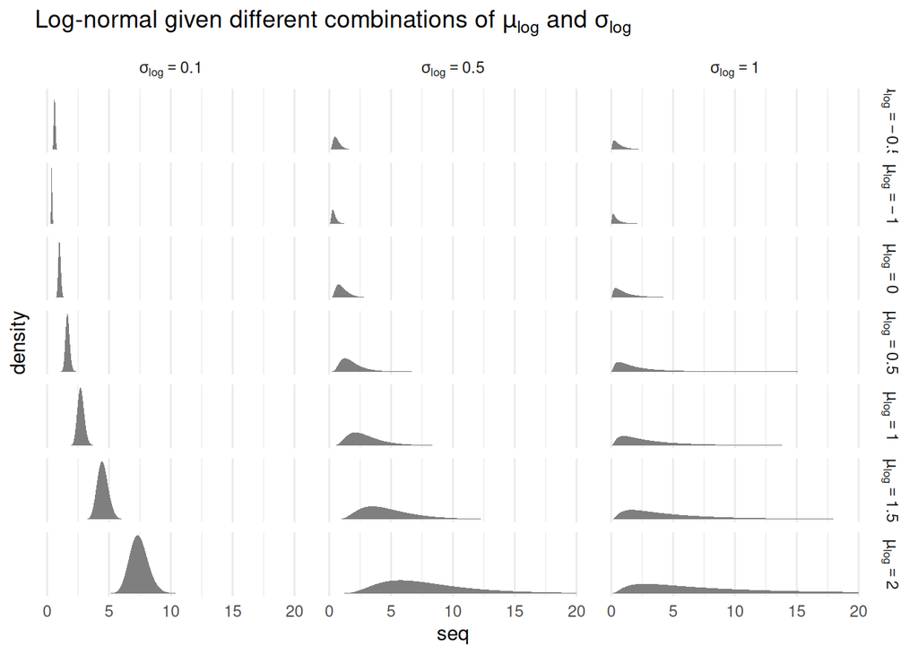

```r
expand_grid(meanlog = seq(-1, 2, by = 0.5),
            sdlog = c(0.1, 0.5, 1),
            seq = seq(from = 0, to = 20, length.out = 400)) |>
  mutate(d   = dlnorm(seq, meanlog, sdlog),
         mu  = str_c("mu[log]==", meanlog),
         sigma = str_c("sigma[log]==", sdlog)) |>
  ggplot(aes(x = seq, y = d)) +
  geom_area(fill = "grey50") +
  scale_y_continuous("density", breaks = NULL) +
  ggtitle(expression("Log-normal given different combinations of "*mu[log]*" and "*sigma[log])) +
  facet_grid(mu ~ sigma, labeller = label_parsed, scales = "free")
```

We can see that the default prior, with the predictors at their means, the median value is likely change over more than four orders of magnitude (for scaled traits). This is far too wide.

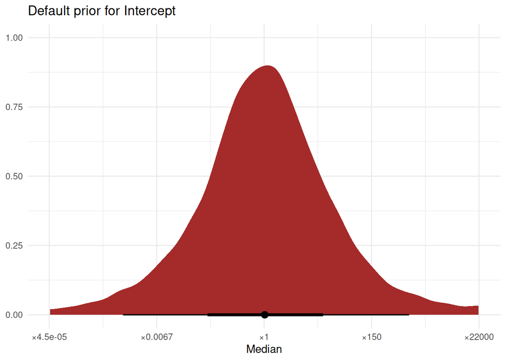

```r
tibble(x = rstudent_t(1e4, 3, 0, 2.5)) |>
  ggplot(aes(x = x)) +
  stat_halfeye(fill = "brown") +
  scale_x_continuous(labels = \(x) str_c("\u00d7", signif(exp(x), 2)),
                     limits = c(-10, 10)) +
  labs(title = "Default prior for Intercept",
       x = "Median",
       y = NULL)
```

The adjusted prior is still wide but more reasonable.

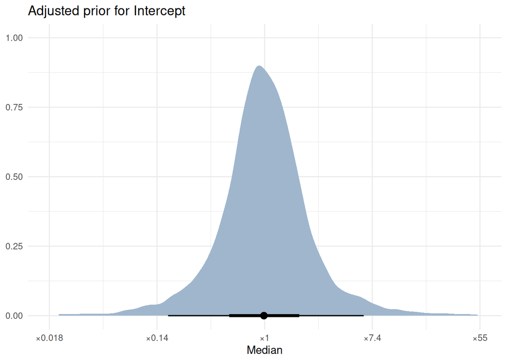

```r
tibble(x = rstudent_t(1e4, 3, 0, 0.6)) |>
  ggplot(aes(x = x)) +
  stat_halfeye(fill = "slategray3") +
  scale_x_continuous(labels = \(x) str_c("\u00d7", signif(exp(x), 2)),
                     limits = c(-4, 4)) +
  labs(title = "Adjusted prior for Intercept",
       x = "Median",
       y = NULL)
```

Here’s the proposed prior for $\beta$ in relative terms:

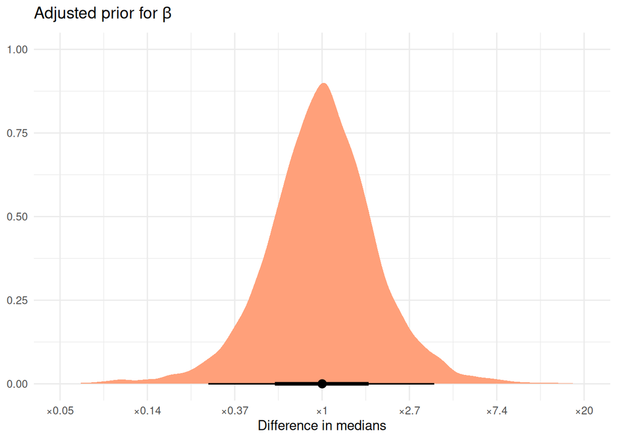

```r
tibble(x = rstudent_t(1e4, 5, 0, 0.5)) |>
  ggplot(aes(x = x)) +
  stat_halfeye(fill = "lightsalmon") +
  scale_x_continuous(labels = \(x) str_c("\u00d7", signif(exp(x), 2)),
                     limits = c(-3, 3),
                     breaks = -3:3) +
  labs(title = expression("Adjusted prior for"~beta),
       x = "Difference in medians",
       y = NULL)
```

And for $\sigma$:

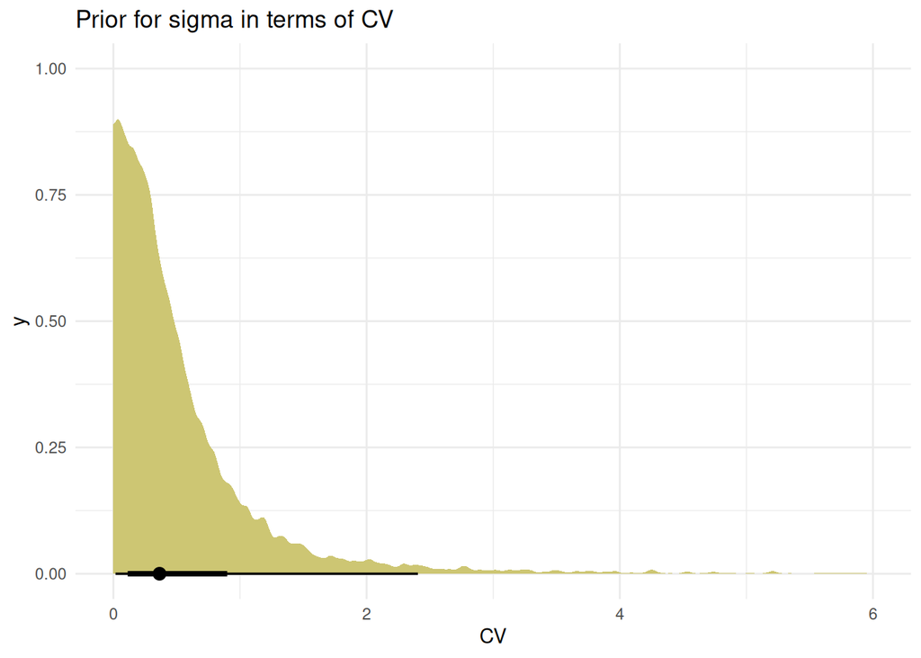

```r
tibble(r = generate(dist_truncated(dist_student_t(5, 0, 0.5), 0), 1e4)[[1]],
       x = sqrt(exp(r^2) - 1)) |>
  ggplot(aes(x = x)) +
  stat_halfeye(fill = "khaki3") +
  xlim(NA, 6) +
  labs(title = "Prior for sigma in terms of CV",
       x = "CV")
```

## 2.3 Hurdle

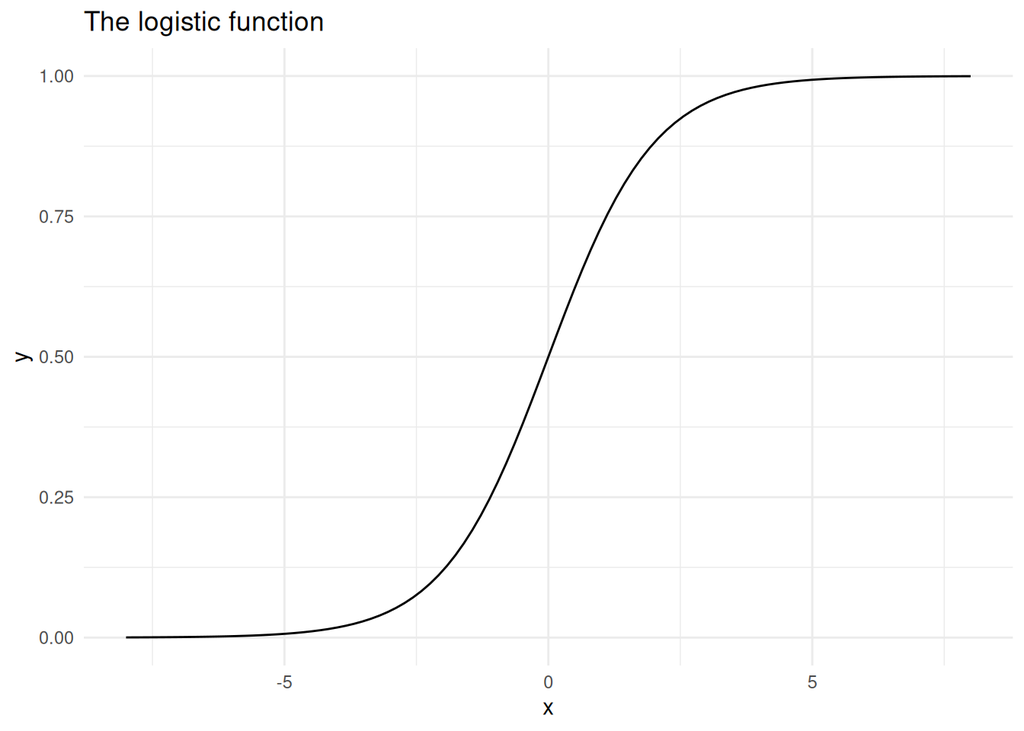

```r
ggplot()+
  geom_function(fun = plogis) +
  xlim(-8, 8) +
  ggtitle("The logistic function")
```

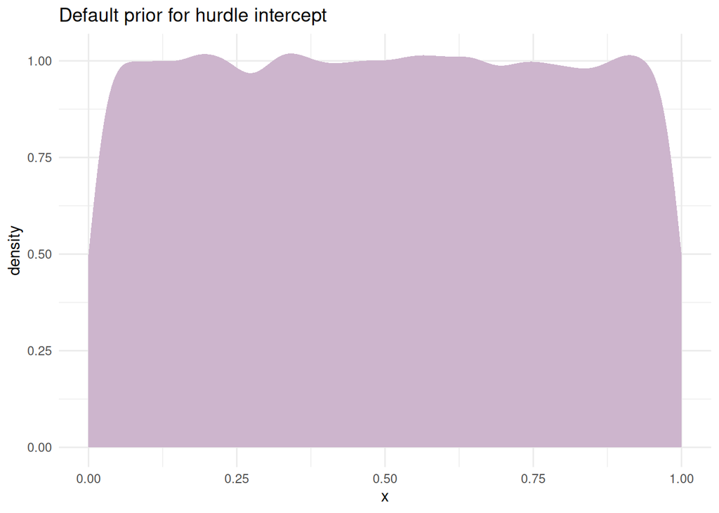

```r
tibble(x = rlogis(1e5, 0, 1) |> plogis()) |>
  ggplot(aes(x = x)) +
  geom_density(fill = "thistle3", colour = NA) +
  ggtitle("Default prior for hurdle intercept")
```

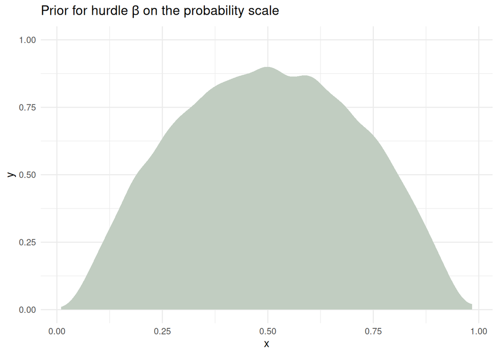

```r
tibble(x = rnorm(1e5, 0, 1) |> plogis()) |>
  ggplot(aes(x = x)) +
  stat_slab(fill = "honeydew3") +
  ggtitle(expression("Prior for hurdle"~beta~"on the probability scale"))
```

## 2.4 Store the priors

The following function emulates the default behaviour of `brms` for the intercept prior, using the outcome median as mean, but using the adjusted df and sd.

```r
#prior for gaussian models
prior_itp <- c(prior(normal(0, 1), class = "b"),
               prior(student_t(3, 0, 0.7), class = "b", coef = "site1"),
               prior(student_t(3, 0, 0.7), class = "b", coef = "site2"),
               prior(student_t(3, 0, 0.5), class = "sigma", lb = 0))

#prior for lognormal models
prior_ln <- function(outcome, hu = F){
  md <- outcome |> median() |> log() |> round(3)
  prior <- c(set_prior(str_c("student_t(3, ", md, ", 0.6)"), class = "Intercept"),
             prior(student_t(5, 0, 0.5), class = "b"),
             prior(student_t(5, 0, 0.5), class = "sigma", lb = 0))

  if(hu) prior <- c(prior, prior(normal(0,1), class = "b", dpar = "hu"))
  return(prior)
}
```

## 2.5 Prior predictive simulation

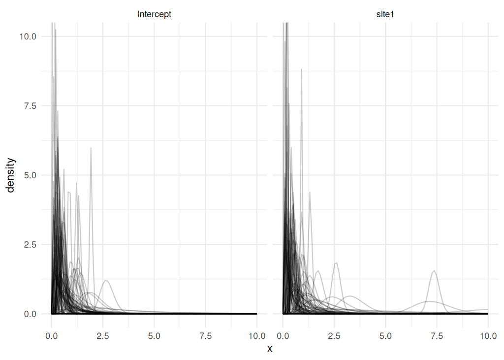

```r
data_prior <- tibble(x = seq(-2, 2, length.out = 10),
                     cover = seq(0, 4, length.out = 10)) |>
  expand_grid(outcome = c(0, 1),
              z = seq(-2, 2, length.out = 10),
              site = letters[1:4])

prior_pred <- brm(bf(outcome ~ x + z + x:z + cover + site,
                     hu ~ x + z + x:z + cover + site),
             data = data_prior,
             prior = prior_ln(data_prior$outcome, hu = T),
             sample_prior = "only",
             family = "hurdle_lognormal",
             file = "fits/prior_h_ln",
             seed = 2853)

#lognormal model
prior_pred |>
  spread_draws(Intercept, b_site1, sigma) |>
  slice_sample(n = 100) |>
  mutate(site1 = Intercept + b_site1) |>
  pivot_longer(c(Intercept, site1)) |>
  expand_grid(x = seq(0, 10, length.out = 100)) |>
  mutate(density = dlnorm(x, value, sigma)) |>
  ggplot(aes(x = x, y = density, group = .draw)) +
  geom_line(alpha = 0.2) +
  coord_cartesian(ylim = c(0, 10)) +
  facet_wrap(vars(name))
```

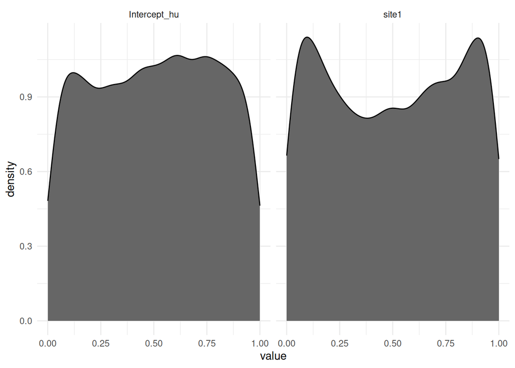

```r
#hurdle model
prior_pred |>
  spread_draws(Intercept_hu, b_hu_site1) |>
  mutate(site1 = Intercept_hu + b_hu_site1) |>
  pivot_longer(c(Intercept_hu, site1)) |>
  mutate(value = plogis(value)) |>
  ggplot(aes(x = value)) +
  geom_density(fill = "grey40") +
  facet_wrap(vars(name))
```

# 3 Years included in the models

The years considered across all models are:

```r
years_across <- cwm_ITP$data |>
  map(1) |>
  bind_rows() |>
  distinct(year) |>
  mutate(year = as.character(year)) |>
  arrange(year) |>
  pull()

years_across
```

```
[1] "2000" "2001" "2002" "2005" "2006" "2008" "2011"
```

This corresponds to a timespan of 12 years.

The years included are the same for all models:

```r
cwm_ITP |>
  mutate(years_diff = map_dbl(data,
                              \(x) x |>
                                pluck(1) |>
                                distinct(year) |>
                                mutate(year = as.character(year)) |>
                                pull() |>
                                setdiff(years_across) |>
                                length())) |>
  select(!data)
```

| trait | years_diff |
| --- | --- |
| BBRsize | 0 |
| offspring | 0 |
| spread | 0 |
| persistence | 0 |
| la | 0 |
| ln | 0 |
| ph | 0 |
| sla | 0 |
| ssd | 0 |
| sm | 0 |

while the number of site-years differs because of different trait filtering

```r
cwm_ITP |>
  mutate(site_years = map_dbl(data,
                              \(x) x |>
                                pluck(1) |>
                                distinct(site, year) |>
                                nrow())) |>
  select(!data)
```

| trait | site_years |
| --- | --- |
| BBRsize | 21 |
| offspring | 21 |
| spread | 21 |
| persistence | 21 |
| la | 21 |
| ln | 16 |
| ph | 21 |
| sla | 21 |
| ssd | 15 |
| sm | 17 |

# 4 Prepare data

```r
variables <- c("air_t_mean", "soil_t_mean", "precipitation")

sds <- c(2.5, 2.5, 600) |>
  set_names(variables)

prepare <- function(data, out, vars = variables) {

  #some processing is applied to both exposure and outcome
  full_var <- c(out, vars)

  # SD for the outcome
  sds <- data[[1]] |>
    summarise(sd_out = sd(.data[[out]])) |>
    pull(sd_out) |>
    set_names(out) |>
    c(sds)

  data |>
    map(\(x) {
      x |>
        mutate(across(all_of(full_var),
                      \(x) sds[[cur_column()]],
                      .names = "{.col}_sd"),
               across(all_of(full_var),
                      \(x) x / sds[[cur_column()]]),
               #cover as proportion 0-4
               cover = cover / 100 * 4) |>
        # calculate site grand means
        mutate(across(all_of(vars), mean,
                      .names = "{.col}_site"),
               across(all_of(vars),
                      \(x) x - get(str_c(cur_column(), "_site")),
                      .names = "{.col}_centered"),
               .by = site)
    })
}

cwm_ITP <- cwm_ITP |>
  mutate(data = map2(data, trait, prepare) |>
           set_names(trait))
```

# 5 Sub-canopy weather

## 5.1 Leaf area

```r
fit_la_itp <- brm_multiple(la | weights(cov_wt, scale = TRUE) ~
                             air_t_mean_centered + precipitation_centered +
                             air_t_mean_centered:precipitation_centered + cover + site,
                           data = cwm_ITP$data$la,
                           prior = prior_ln(cwm_ITP$data$la[[1]]$la),
                           family = "lognormal",
                           file = "fits/cwm/la.itp",
                           file_refit = "never",
                           control = list(seed = 2853))

prior_summary(fit_la_itp)
```

| prior | class | coef | group | resp | dpar | nlpar | lb | ub | tag | source |
| --- | --- | --- | --- | --- | --- | --- | --- | --- | --- | --- |
| student_t(5, 0, 0.5) | b |  |  |  |  |  |  |  |  | user |
|  | b | air_t_mean_centered |  |  |  |  |  |  |  | default |
|  | b | air_t_mean_centered:precipitation_centered |  |  |  |  |  |  |  | default |
|  | b | cover |  |  |  |  |  |  |  | default |
|  | b | precipitation_centered |  |  |  |  |  |  |  | default |
|  | b | site1 |  |  |  |  |  |  |  | default |
|  | b | site2 |  |  |  |  |  |  |  | default |
| student_t(3, -2.099, 0.6) | Intercept |  |  |  |  |  |  |  |  | user |
| student_t(5, 0, 0.5) | sigma |  |  |  |  |  | 0 |  |  | user |

```r
fit_la_itp
```

```
 Family: lognormal
  Links: mu = identity
Formula: la | weights(cov_wt, scale = TRUE) ~ air_t_mean_centered + precipitation_centered + air_t_mean_centered:precipitation_centered + cover + site
   Data: cwm_ITP$data$la (Number of observations: 364)
  Draws: 20 chains, each with iter = 2000; warmup = 1000; thin = 1;
         total post-warmup draws = 20000

Regression Coefficients:
                                           Estimate Est.Error l-95% CI u-95% CI
Intercept                                     -1.49      1.73    -4.67     2.21
air_t_mean_centered                           -0.32      0.39    -1.12     0.40
precipitation_centered                         0.21      0.15    -0.08     0.51
cover                                         -0.35      0.48    -1.37     0.53
site1                                         -0.69      0.12    -0.92    -0.46
site2                                         -0.56      0.14    -0.85    -0.28
air_t_mean_centered:precipitation_centered    -0.04      0.44    -0.93     0.82

Further Distributional Parameters:
      Estimate Est.Error l-95% CI u-95% CI
sigma     1.49      0.06     1.39     1.60

Draws were sampled using sample(hmc). Overall Rhat and ESS estimates
are not informative for brm_multiple models and are hence not displayed.
Please see ?brm_multiple for how to assess convergence of such models.
```

```r
multiple_convergence(fit_la_itp)
```

| variable | rhat | ess_bulk | ess_tail |
| --- | --- | --- | --- |
| b_Intercept | 1 | 3160 | 2518 |
| b_air_t_mean_centered | 1 | 4583 | 2783 |
| b_precipitation_centered | 1 | 4489 | 2984 |
| b_cover | 1 | 3144 | 2610 |
| b_site1 | 1 | 3349 | 2834 |
| b_site2 | 1 | 2781 | 2220 |
| b_air_t_mean_centered:precipitation_centered | 1 | 4450 | 2730 |
| sigma | 1 | 5365 | 2863 |
| Intercept | 1 | 4702 | 2855 |

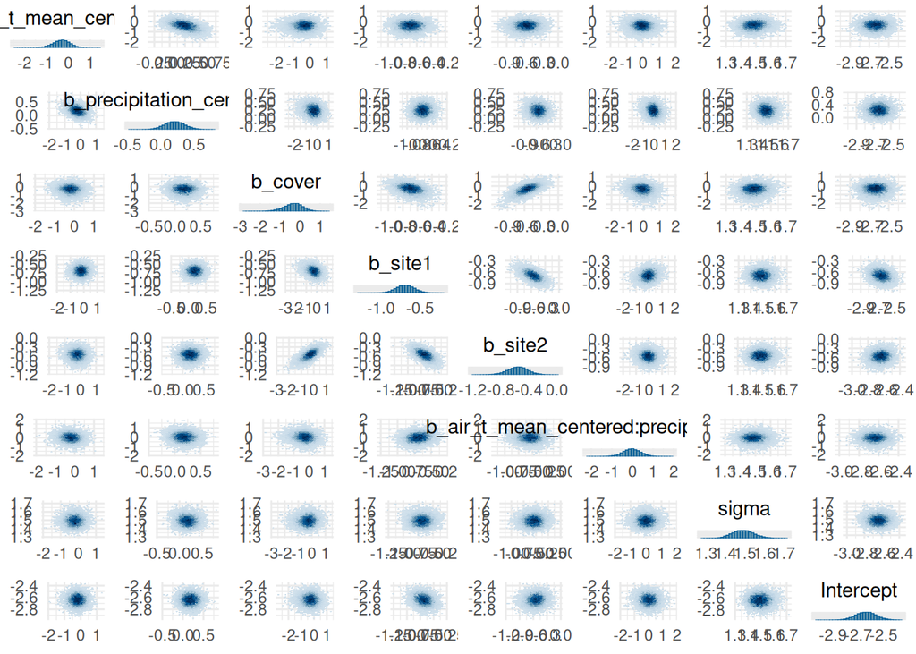

```r
my_mcmc_pairs(fit_la_itp)
```

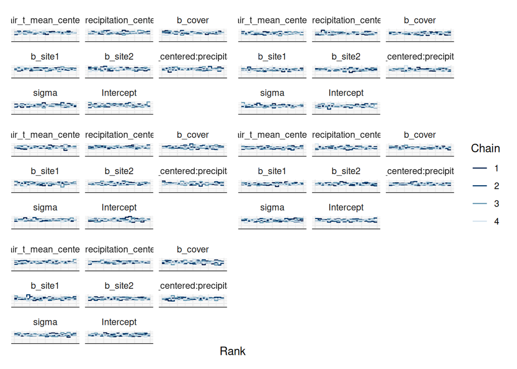

```r
trank(fit_la_itp)
```

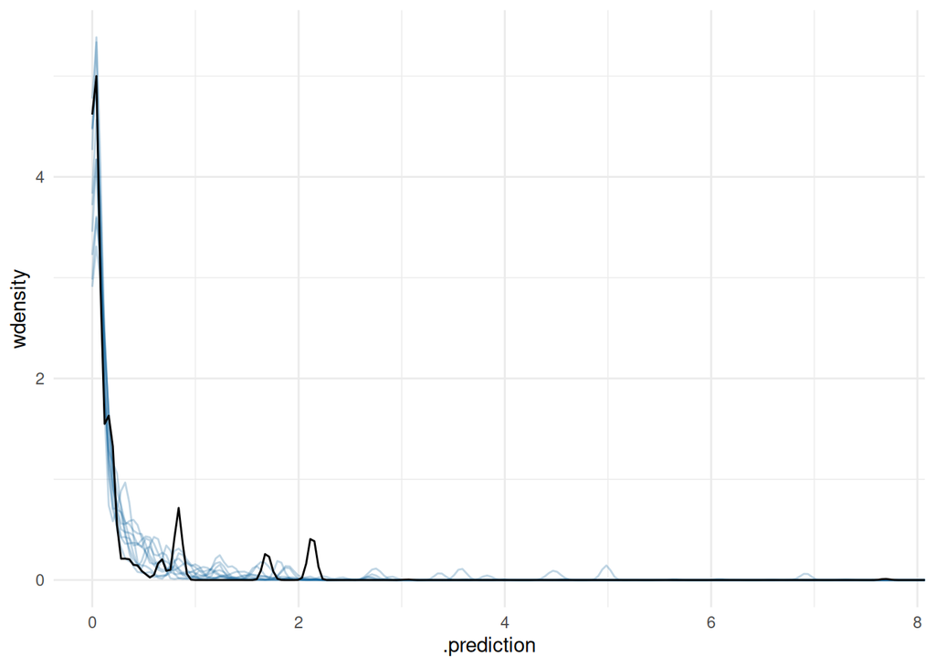

```r
my_ppc(fit_la_itp, cwm_ITP$data$la)
```

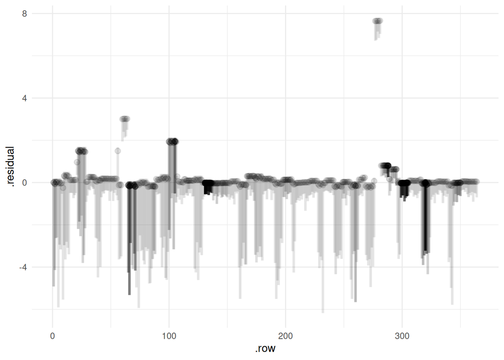

```r
my_resplot(fit_la_itp, cwm_ITP$data$la[[1]])
```

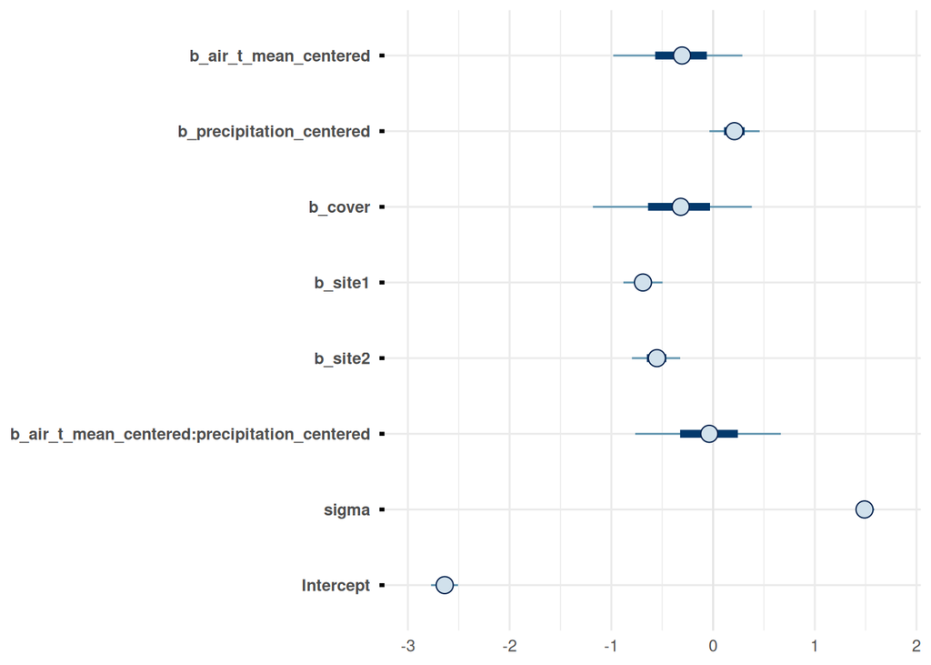

```r
mcmc_intervals(fit_la_itp, pars = show)
```

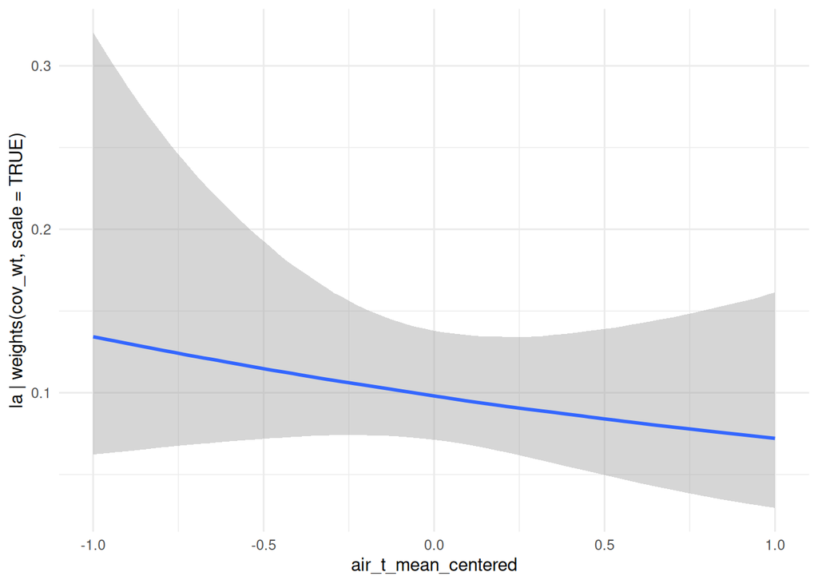

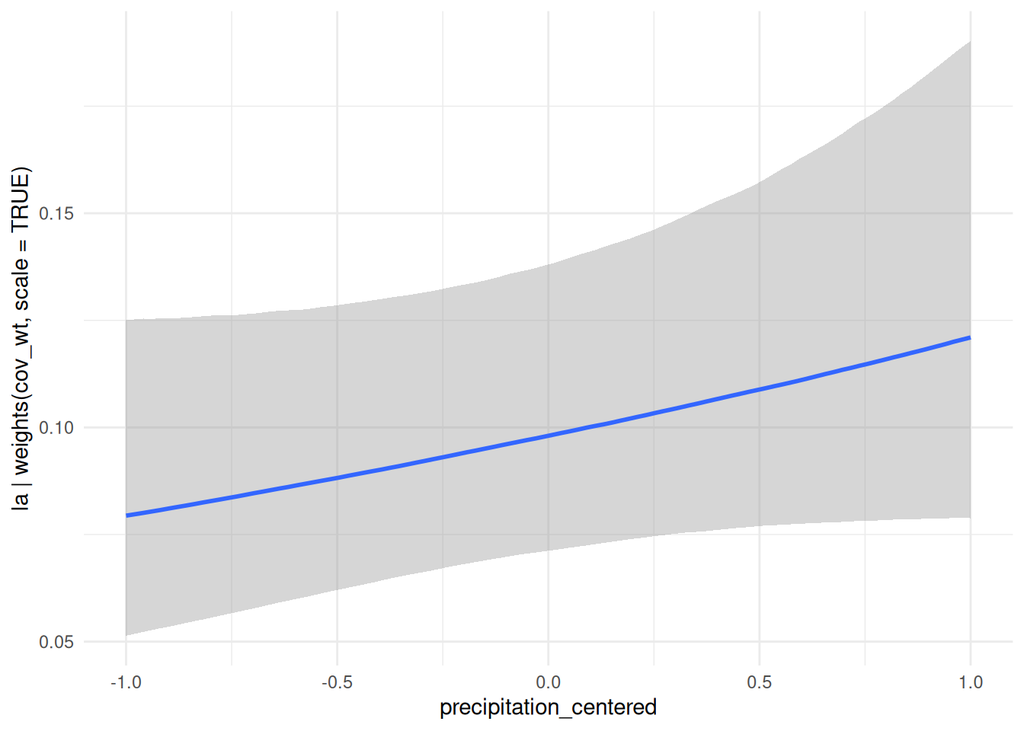

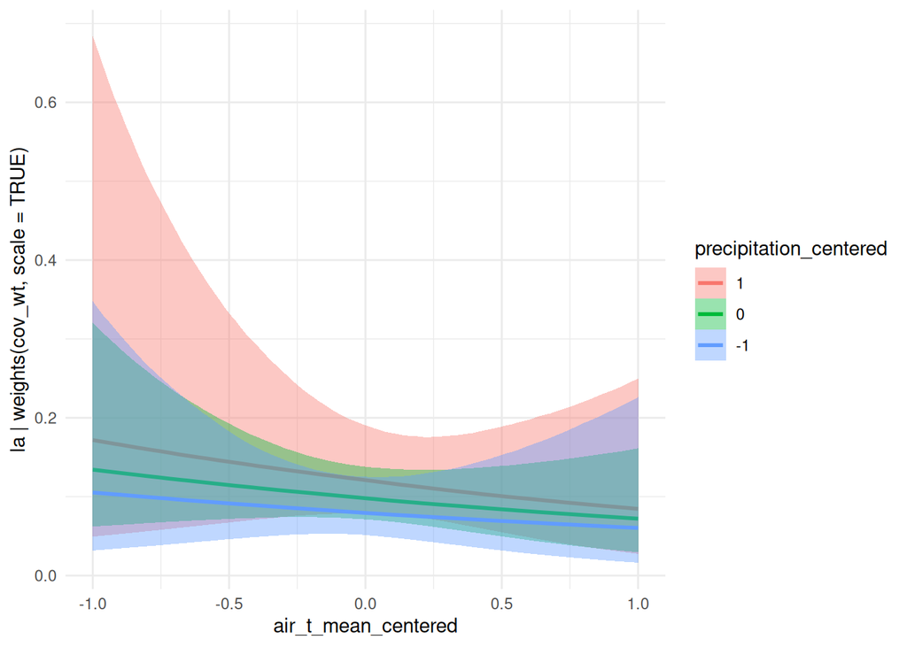

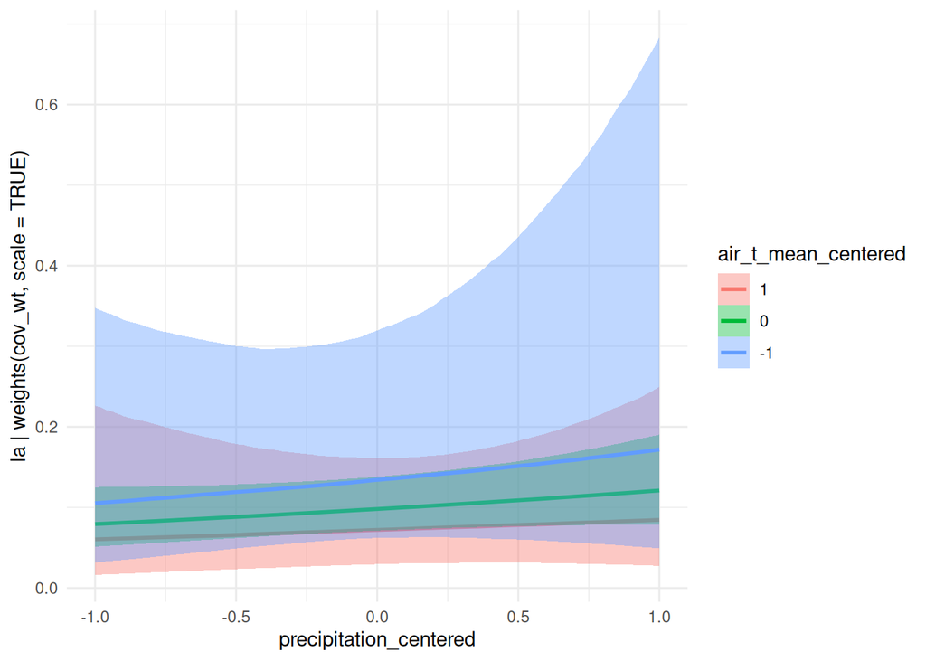

```r
my_ceffects(fit_la_itp)
```

## 5.2 Leaf nitrogen

```r
fit_ln_itp <- brm_multiple(ln | weights(cov_wt, scale = TRUE) ~
                             air_t_mean_centered + precipitation_centered +
                             air_t_mean_centered:precipitation_centered + cover + site,
                           data = cwm_ITP$data$ln,
                           prior = prior_ln(cwm_ITP$data$ln[[1]]$ln),
                           family = "lognormal",
                           file = "fits/cwm/ln.itp",
                           file_refit = "never",
                           control = list(seed = 2853))

prior_summary(fit_ln_itp)
```

| prior | class | coef | group | resp | dpar | nlpar | lb | ub | tag | source |
| --- | --- | --- | --- | --- | --- | --- | --- | --- | --- | --- |
| student_t(5, 0, 0.5) | b |  |  |  |  |  |  |  |  | user |
|  | b | air_t_mean_centered |  |  |  |  |  |  |  | default |
|  | b | air_t_mean_centered:precipitation_centered |  |  |  |  |  |  |  | default |
|  | b | cover |  |  |  |  |  |  |  | default |
|  | b | precipitation_centered |  |  |  |  |  |  |  | default |
|  | b | site1 |  |  |  |  |  |  |  | default |
|  | b | site2 |  |  |  |  |  |  |  | default |
| student_t(3, 1.31, 0.6) | Intercept |  |  |  |  |  |  |  |  | user |
| student_t(5, 0, 0.5) | sigma |  |  |  |  |  | 0 |  |  | user |

```r
fit_ln_itp
```

```
 Family: lognormal
  Links: mu = identity
Formula: ln | weights(cov_wt, scale = TRUE) ~ air_t_mean_centered + precipitation_centered + air_t_mean_centered:precipitation_centered + cover + site
   Data: cwm_ITP$data$ln (Number of observations: 244)
  Draws: 20 chains, each with iter = 2000; warmup = 1000; thin = 1;
         total post-warmup draws = 20000

Regression Coefficients:
                                           Estimate Est.Error l-95% CI u-95% CI
Intercept                                      1.19      0.33     0.51     1.83
air_t_mean_centered                            0.01      0.05    -0.09     0.11
precipitation_centered                        -0.01      0.02    -0.04     0.03
cover                                          0.03      0.09    -0.14     0.22
site1                                         -0.05      0.02    -0.08    -0.01
site2                                          0.10      0.02     0.06     0.15
air_t_mean_centered:precipitation_centered    -0.10      0.14    -0.38     0.16

Further Distributional Parameters:
      Estimate Est.Error l-95% CI u-95% CI
sigma     0.13      0.01     0.12     0.15

Draws were sampled using sample(hmc). Overall Rhat and ESS estimates
are not informative for brm_multiple models and are hence not displayed.
Please see ?brm_multiple for how to assess convergence of such models.
```

```r
multiple_convergence(fit_ln_itp)
```

| variable | rhat | ess_bulk | ess_tail |
| --- | --- | --- | --- |
| b_Intercept | 1 | 1818 | 2272 |
| b_air_t_mean_centered | 1 | 3108 | 2573 |
| b_precipitation_centered | 1 | 3356 | 2800 |
| b_cover | 1 | 1812 | 2386 |
| b_site1 | 1 | 2188 | 2646 |
| b_site2 | 1 | 1920 | 2229 |
| b_air_t_mean_centered:precipitation_centered | 1 | 2549 | 3040 |
| sigma | 1 | 3435 | 2435 |
| Intercept | 1 | 3816 | 2645 |

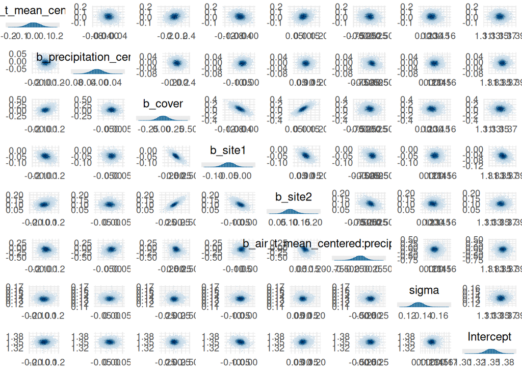

```r
my_mcmc_pairs(fit_ln_itp)
```

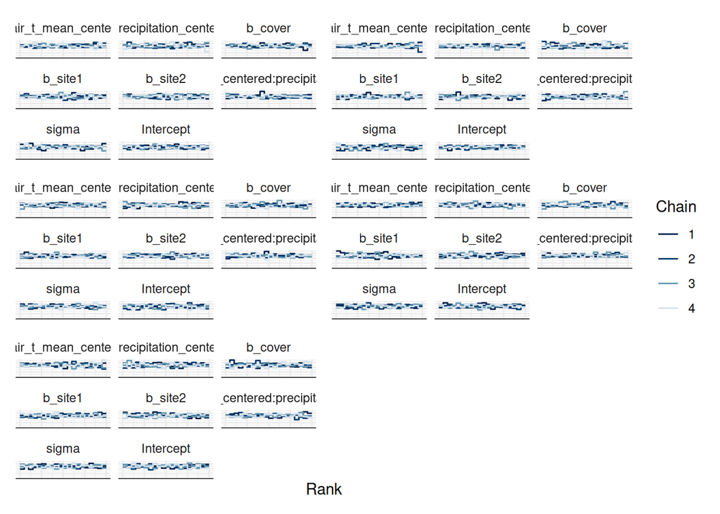

```r
trank(fit_ln_itp)
```

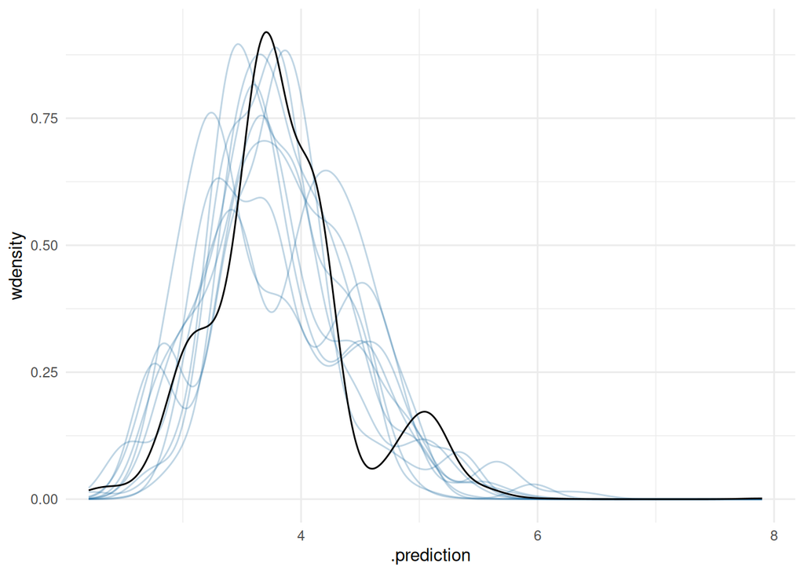

```r
my_ppc(fit_ln_itp, cwm_ITP$data$ln)
```

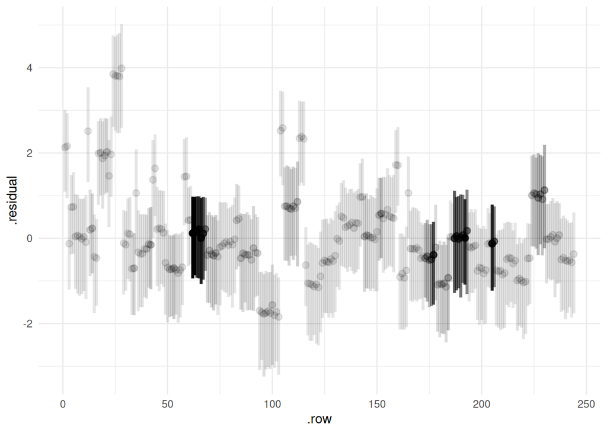

```r
my_resplot(fit_ln_itp, cwm_ITP$data$ln[[1]])
```

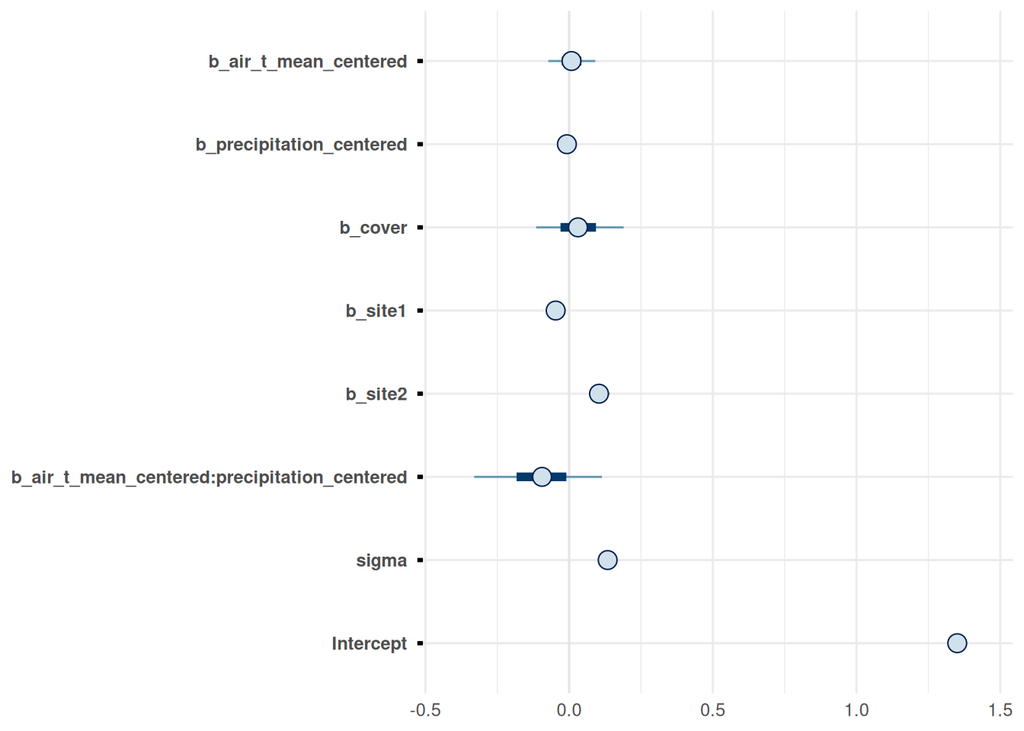

```r
mcmc_intervals(fit_ln_itp, pars = show)
```

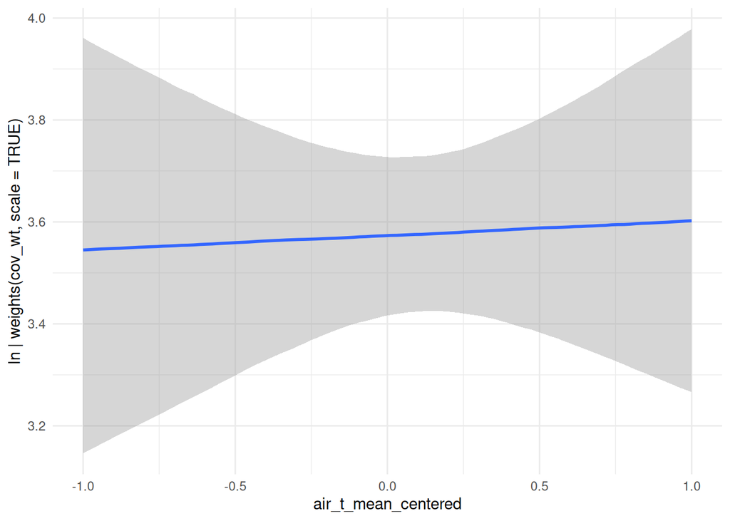

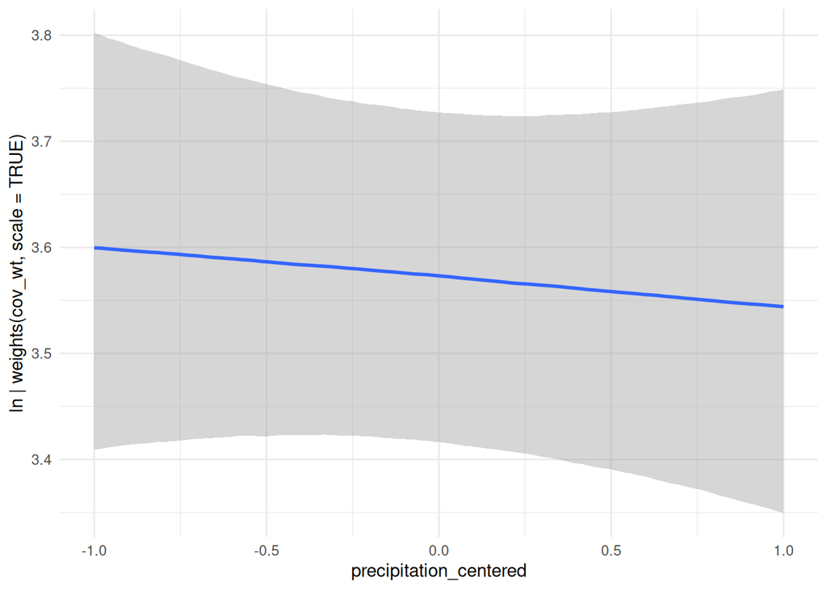

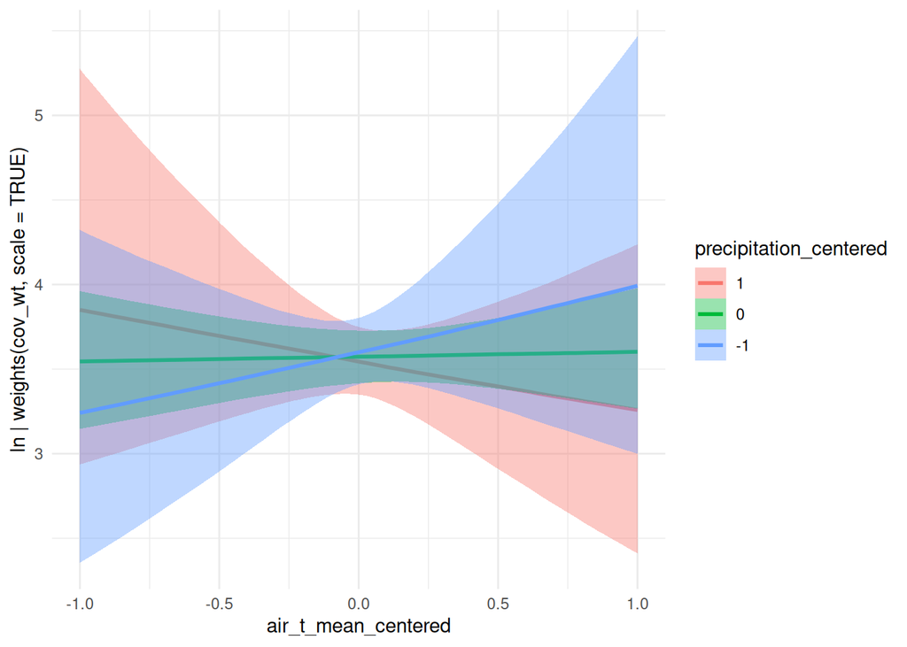

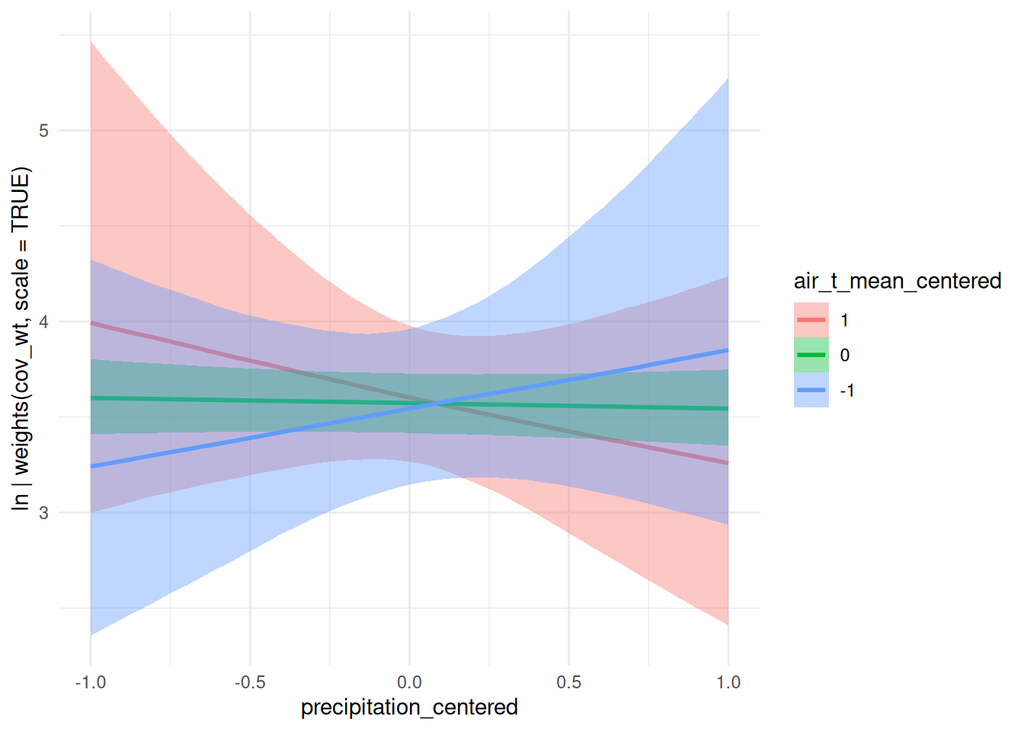

```r
my_ceffects(fit_ln_itp)
```

## 5.3 Plant height

```r
fit_ph_itp <- brm_multiple(ph | weights(cov_wt, scale = TRUE) ~
                             air_t_mean_centered + precipitation_centered +
                             air_t_mean_centered:precipitation_centered + cover + site,
                           data = cwm_ITP$data$ph,
                           prior = prior_ln(cwm_ITP$data$ph[[1]]$ph),
                           family = "lognormal",
                           file = "fits/cwm/ph.itp",
                           file_refit = "never",
                           control = list(seed = 2853))

prior_summary(fit_ph_itp)
```

| prior | class | coef | group | resp | dpar | nlpar | lb | ub | tag | source |
| --- | --- | --- | --- | --- | --- | --- | --- | --- | --- | --- |
| student_t(5, 0, 0.5) | b |  |  |  |  |  |  |  |  | user |
|  | b | air_t_mean_centered |  |  |  |  |  |  |  | default |
|  | b | air_t_mean_centered:precipitation_centered |  |  |  |  |  |  |  | default |
|  | b | cover |  |  |  |  |  |  |  | default |
|  | b | precipitation_centered |  |  |  |  |  |  |  | default |
|  | b | site1 |  |  |  |  |  |  |  | default |
|  | b | site2 |  |  |  |  |  |  |  | default |
| student_t(3, 0.241, 0.6) | Intercept |  |  |  |  |  |  |  |  | user |
| student_t(5, 0, 0.5) | sigma |  |  |  |  |  | 0 |  |  | user |

```r
fit_ph_itp
```

```
 Family: lognormal
  Links: mu = identity
Formula: ph | weights(cov_wt, scale = TRUE) ~ air_t_mean_centered + precipitation_centered + air_t_mean_centered:precipitation_centered + cover + site
   Data: cwm_ITP$data$ph (Number of observations: 368)
  Draws: 20 chains, each with iter = 2000; warmup = 1000; thin = 1;
         total post-warmup draws = 20000

Regression Coefficients:
                                           Estimate Est.Error l-95% CI u-95% CI
Intercept                                      0.39      0.84    -1.26     2.07
air_t_mean_centered                            0.09      0.14    -0.19     0.36
precipitation_centered                        -0.03      0.05    -0.13     0.08
cover                                         -0.05      0.23    -0.52     0.40
site1                                         -0.09      0.04    -0.17    -0.00
site2                                          0.04      0.06    -0.08     0.16
air_t_mean_centered:precipitation_centered    -0.18      0.24    -0.67     0.29

Further Distributional Parameters:
      Estimate Est.Error l-95% CI u-95% CI
sigma     0.50      0.02     0.47     0.54

Draws were sampled using sample(hmc). Overall Rhat and ESS estimates
are not informative for brm_multiple models and are hence not displayed.
Please see ?brm_multiple for how to assess convergence of such models.
```

```r
multiple_convergence(fit_ph_itp)
```

| variable | rhat | ess_bulk | ess_tail |
| --- | --- | --- | --- |
| b_Intercept | 1 | 2348 | 2440 |
| b_air_t_mean_centered | 1 | 3472 | 2643 |
| b_precipitation_centered | 1 | 3336 | 2695 |
| b_cover | 1 | 2334 | 2503 |
| b_site1 | 1 | 2495 | 2645 |
| b_site2 | 1 | 2202 | 2386 |
| b_air_t_mean_centered:precipitation_centered | 1 | 2995 | 2478 |
| sigma | 1 | 3244 | 2309 |
| Intercept | 1 | 3401 | 2512 |

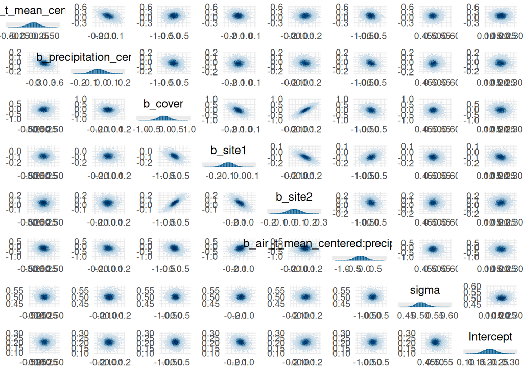

```r
my_mcmc_pairs(fit_ph_itp)
```

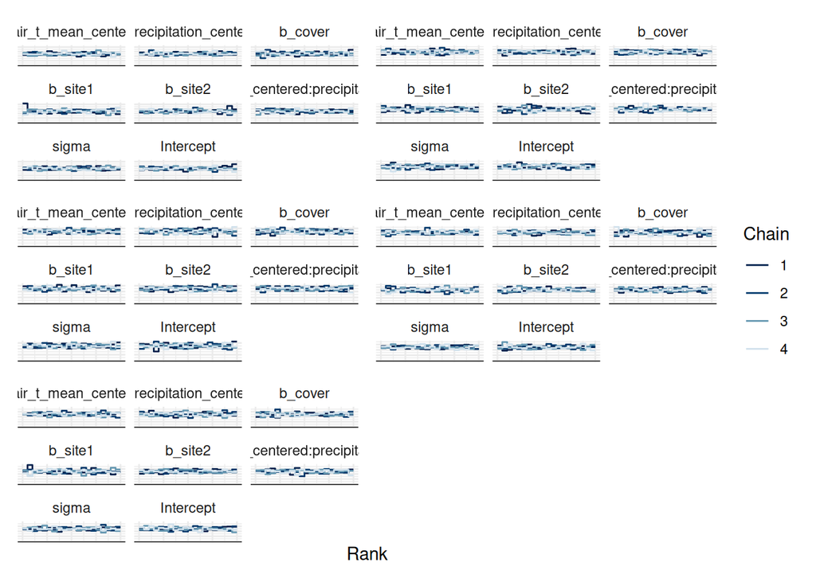

```r
trank(fit_ph_itp)
```